# Evaluation of Machine Learning Models for Thyroid Cancer Recurrence Prediction

Zey Sarioglan, Danielle Liu, and Diljeet Kaur

Due 2025-05-4

# 1 Executive Summary

Exploratory data analysis revealed a significant class imbalance in the target variable (Recurred), suggesting the use of SMOTE (Synthetic Minority Oversampling Technique) to balance the training set. Several predictors were strongly associated with recurrence, particularly treatment response, cancer stage, age, risk classification, and lymph node involvement.

We developed and compared three machine learning models: (1) logistic regression (with LASSO and backward selection), (2) neural network, and (3) random forest. Their performance was assessed based on AUC and accuracy using the test set.

### 1.0.1 Introduction

Thyroid cancer is one of the most common endocrine malignancies, and while treatment is often effective, **recurrence remains a significant clinical concern.** Accurately predicting which patients are at higher risk for recurrence can greatly enhance long-term management and follow-up strategies.

**This project aims to develop machine learning models to predict thyroid cancer recurrence and to identify key predictive variables associated with recurrence risk.** By uncovering these factors, we hope to inform more personalized and effective approaches to patient care and treatment planning.

### 1.0.2 Objectives

**Overall Question**

- What are the risk factors for thyroid cancer recurrence?

**Primary Research Question**

- What machine learning models can best predict thyroid cancer recurrence based on the variables in our data set?

**Sub-Research Questions**

1. Are thyroid cancer recurrences more common in men or women?
2. How does age affect recurrence risk?
3. Can we predict recurrence based on tumor staging and pathology?
4. What is the relationship between treatment response and recurrence?

### 1.0.3 Summary of Exploratory Data Analysis and Data Visualization

- The outcome variable of interest, `Recurred`, is **highly imbalanced**:
  - 275 patients did **NOT** recur
  - 108 patients **did** recur
  - This imbalance motivated our use of **SMOTE** to **balance the training data prior to model training** (which we explained further in the Analysis section of the report).
- Our analysis identified several variables that are **strongly associated and/or correlated** with cancer recurrence (via Cramér’s V and correlation analysis):
  - `Response` to treatment (strongest association)
  - `Stage` of cancer (a very strong association - specifically for Stage I)
  - Older `Age` is also associated with higher recurrence risk
  - `Risk` classification
  - Tumor classification (`T`)
  - Lymph node involvement (`N`)
  - `Adenopathy` status
- We provide visual confirmations of the associations between `Recurred` and `Response`, `Stage`, and `Age`.
- Our exploration also revealed inter-variable relationships that we should keep aware for modeling to avoid multicolinearity. These include the following:
  - `Stage` (Stage I) and `Age` (which we provide visual confirmation of)
  - `Stage` and `Risk` (Risk_High)
  - `Adenopathy` and `Risk`
  - `Adenopathy` and `N` (N_N1b)
  - `M` and `Risk` (High Risk)
  - `Gender` and `Smoking`
  - `M` and `Stage` (Stage_IVB)
- These insights from EDA directly informed model design in the subsequent analysis phase.


### 1.0.5 Conclusions

We combined exploratory data analysis with three machine learning methods in our investigation to explore and predict thyroid cancer recurrence outcomes. The exploratory analysis revealed key clinical variables (i.e., treatment response, cancer stage, tumor classification, lymph node involvement, and patient age) that are strongly associated with recurrence. We also identified several inter-variable associations that required attention to avoid multicollinearity during modeling.

To address the class imbalance in the outcome variable (Recurred), we applied SMOTE (Synthetic Minority Oversampling Technique) to the training data set prior to model training. This step was important to improve model performance and ensure non-biased training. The performance of three models (1) logistic regression (with LASSO and backward selection), (2) a neural network, and (3) a random forest was then compared using AUC and accuracy on the test data.

Overall, this analysis highlights the feasibility of using machine learning to predict thyroid cancer recurrence and supports the clinical relevance of several key patient characteristics. The next steps could involve external validation, integrating temporal or genetic data, and exploring how these models might support clinical decision-making in practice.

# 2 Exploratory Data Analysis and Data Visualization

### 2.0.1 Goal: Understand the data set, clean the data set, and visualize the distributions of important variables.

### 2.0.2 EDA Part 0: Data Overview

- This dataset focuses on thyroid cancer recurrence after Radioactive Iodine (RAI) therapy.
- The data was collected over 15 years. Each patient was followed for at least 10 years.
- It contains **383 patient records with 17 key clinicopathologic variables.** The 17 variables are as follows:
  1. Age : Age of the patient (in years).
  2. Gender : Patient’s biological sex (Male or Female).
  3. Smoking : Current Smoking status (Yes or No).
  4. Hx.Smoking : History of smoking (Yes or No).
  5. Hx Radiotherapy : history of radiation therapy to the head and neck region (Yes or No).
  6. Thyroid function (classified as euthyroid, clinical or subclinical hypo/hyperthyroidism),
  7. Physical.Examination : Presence of goiter (thyroid gland englargement) based on physical examination (diffuse, single nodular goiter on the left or right lobe, multinodular, or normal).
  8. Adenopathy : Presence of lymph node involvement based on physical examination. (Yes or no)
  9. Pathology : Pathological subtype of thyroid cancer (papillary, micropapillary, follicular, Hürthle cell).
  10. Focality : Tumor focality (Uni-Focal or Multi-Focal).
  11. Risk : Cancer risk classification according to ATA guidelines (Low, Intermediate, High).
  12. T : Tumor classification (T1, T2, etc.).
  13. N : Lymph node classification (N0, N1, etc.).
  14. M : Metastasis classification (M0, M1, etc.).
  15. Stage : Cancer staging (Stage I, II, III, IA, IVB).
  16. Response : Initial reatment response (excellent, indeterminate, biochemical incomplete, structurally incomplete).
  17. **Recurred : Whether cancer recurred, whether locoregional or distant metastasis (Yes or No).**
- The target variable is `Recurred`, which indicates whether the patient experienced cancer recurrence after treatment.
- Note: **The dataset is unbalanced, with 275 patients not experiencing recurrence and 108 patients experiencing recurrence**.
- This [data set](https://www.kaggle.com/datasets/joebeachcapital/differentiated-thyroid-cancer-recurrence) is a modified version of the original dataset.

### 2.0.3 EDA Part 1: Understanding and Cleaning the Data

- There are 17 variables and 383 observations.
- Variable names include “Age”, “Gender”, “Smoking”, etc.
- There are no missing values.
- All variables are characters except age.

### 2.0.4 EDA Part 2: Visualizing Distributions of Important Categorical Variables

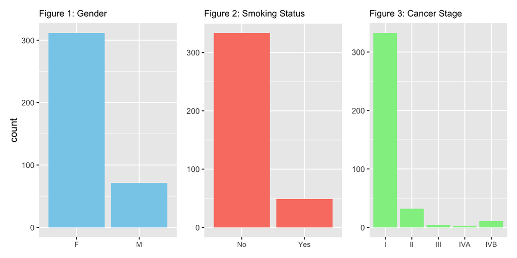

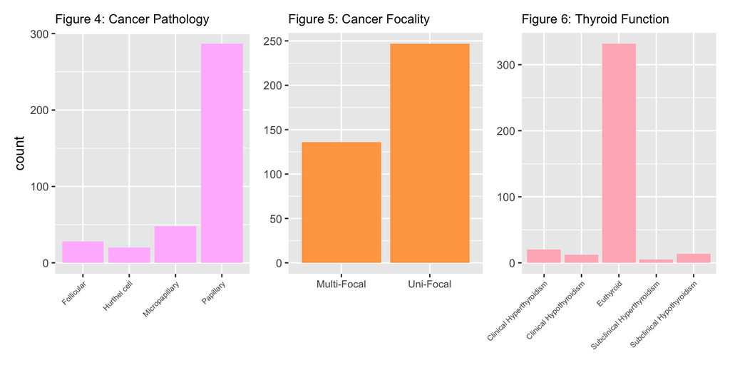

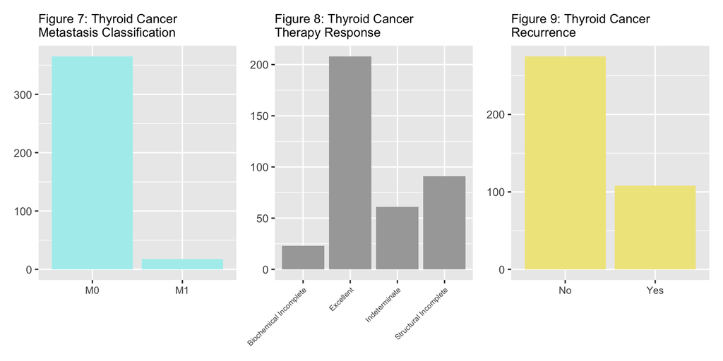

### 2.0.5 EDA Part 3: Visualizing Distribution of Numerical Variable (Age)

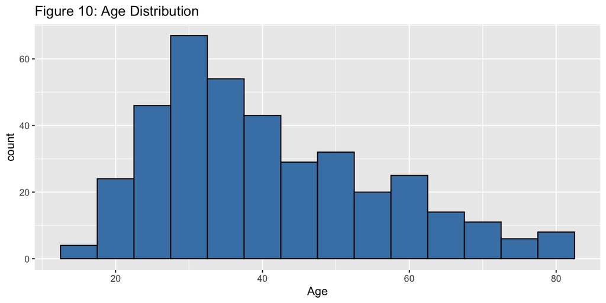

- Figure 10 shows that the Age distribution is right skewed. The median age is 37 years old and the mean age is 40.9 years old. The minimum age and maximum age in the data set are 15 and 82 years old.

### 2.0.6 EDA Part 4: Variable Association Analysis

- We check the association between each of the variables in the dataset.
- Since the dataset is mostly categorical, we used the **Cramer’s V** test to do this, which tests for associations between vairables rather than correlations.
- **Cramer’s V test:** based on Pearson’s chi-squared statistic and is used to measure the strength of association between two categorical variables. The value of Cramér’s V ranges from 0 to 1, where 0 indicates no association and 1 indicates a perfect association.

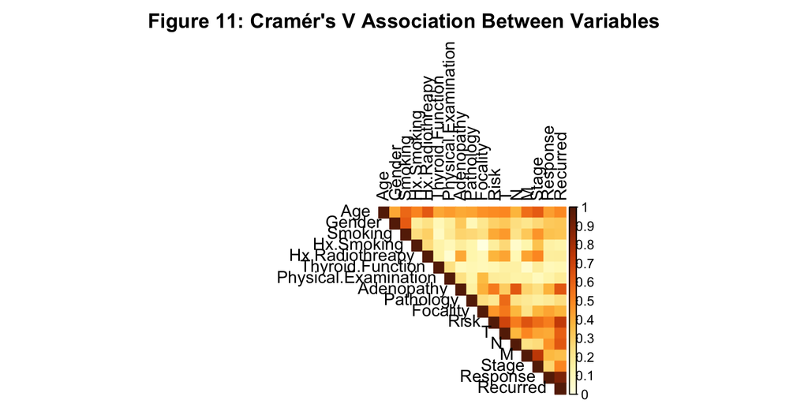

The association plot in Figure 11 show the following:

- The strongest association is between the variable `Response` and the predictor variable `Recurred`. This suggests that the response to treatment is related to the likelihood of recurrence, and our model should account for this.
- Other strong associations with `Recurred` include `Adenopathy`, `Risk`, `T` (tumor clssification), and `N` (Lymph node classification)
- `Stage` and `M` seem to be strongly associated with each other, so we should keep that in mind if they are included in our final model. (To be more specific, if we use dummy variables created from categorical predictors in our regression model(s), and two variables have a high Cramér’s V, that could translate into multicollinearity among those dummy variables.)

### 2.0.7 EDA Part 5: Variable Correlation Analysis

- Here, we check the correlation between every variable in our dataset
- We do this by first performing full **one-hot encoding** on the categorical variables, and then using **Pearson’s correlation** to check the correlation between the one-hot encoded variables.
- Note: **One-hot encoding**: creates binary columns (0 or 1) for each category in the categorical variables.

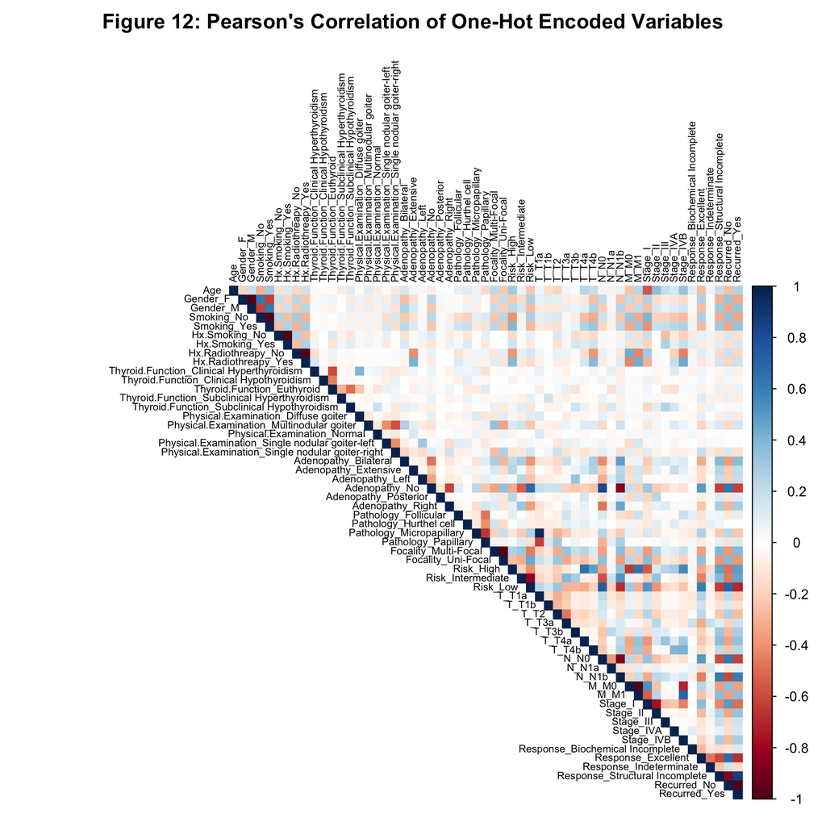

The correlation plot in Figure 12 show the following:

- One of the strongest correlations is between the variable `Response` (Specifically, “Response_Structural_Incomplete” and “Response_Excellent”) and the predictor variable `Recurred`. This suggests that the response to treatment is related to the likelihood of recurrence, and our model should account for this.
- There is also strong correlations between:
  - `Reccured` and `Stage` (Stage_I),
  - `Recurred` and `N` (N0 and N1b)
  - `Recurred` and `Risk` (Risk_Low).
  - `Recurred` and `Adenopathy` (Adenopathy_No)
- Other variables with strong correlation that should be kept in mind during modeling with one-hot encoding due to risk of multicolinaerity:
  - `Age` and `Stage` (Stage I)
  - `Stage` and `Risk` (Risk_High)
  - `Adenopathy` (Adenopathy_No) and `Risk`
  - `Adenopathy` (Adenopathy_No) and `N` (N_N1b)
  - `M` and `Risk` (Risk_High)
  - `Gender` and `Smoking`
  - `M` and `Stage` (Stage_IVB)

### 2.0.8 EDA Part 6: Exploratory visual exploration of the distribution of `Age` by certain important categorical variables

- We are interested in visually detecting whether the distribution of age varies depending on Recurrence status. While the above analysis showed that `Age` and `Recurred` are not strongly associated and correlated, we are still interested in visually exploring their interaction.
- Since we know that `Recurred` and `Reponse` are stongly associated and correlated, we are also interested in visually exploring the interaction between `Age` and `Response`.
- Since we know that `Recurred` and `Stage` are associated and correlated, we are also interested in visually exploring the interaction between `Age` and `Stage`.
- In addition, `Age` and `Hx.Radiotherapy` showed strong association, we investigate how Age differs by Hx.Radiotherapy status. *We use boxplots to visualize the distribution of Age by these categorical variables.

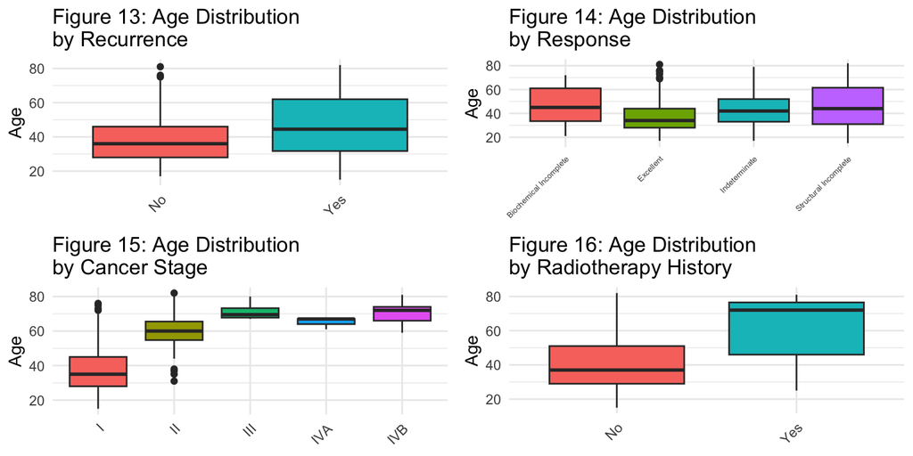

- **Figure 13** shows that the median age for those who have recurred is higher than those that haven’t.
- **Figure 14** shows that there is not substantial difference between patient age and response to treatment.
- **Figure 15** shows that the median age for those with Stage I is lower than those with other stages.
- **Figure 16** shows that the median age for those who have received Radiotherapy is higher than those that haven’t

### 2.0.9 EDA Part 7: Exploratory Visual Comparison of Recurrence by Stage and Treatment Response

- Since `Recurred` is associated with both `Response` and `Stage`, we visually examine how its distribution varies across these variables individually and jointly.
- To explore these patterns, we use stacked bar plots to compare `Recurred` frequencies within `Response` and `Stage` levels and their combination.
- This exploratory visualization may reveal subgroup-specific trends that warrant further exploration in our modeling.

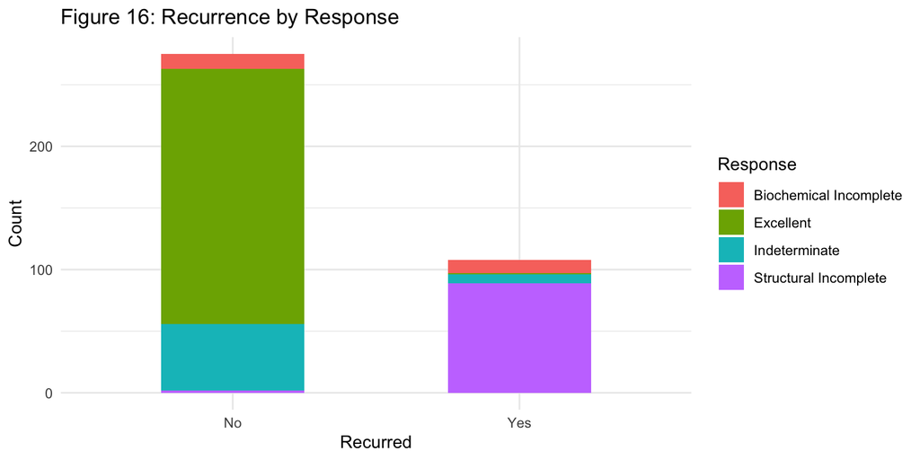

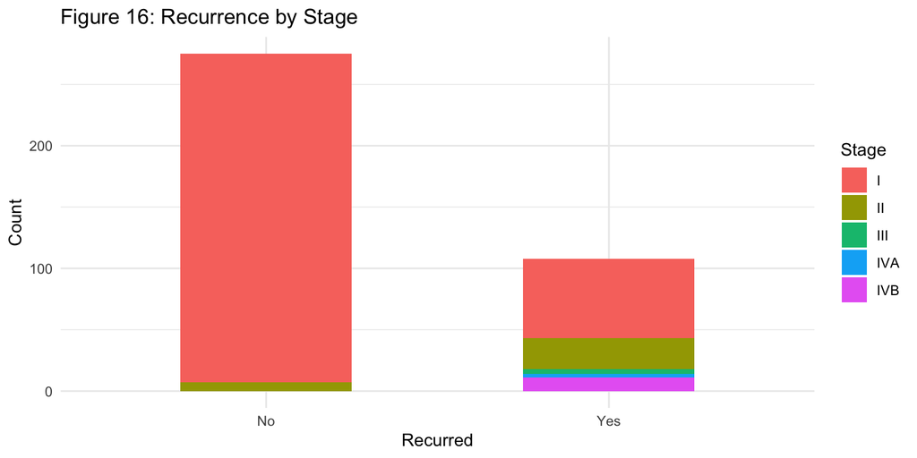

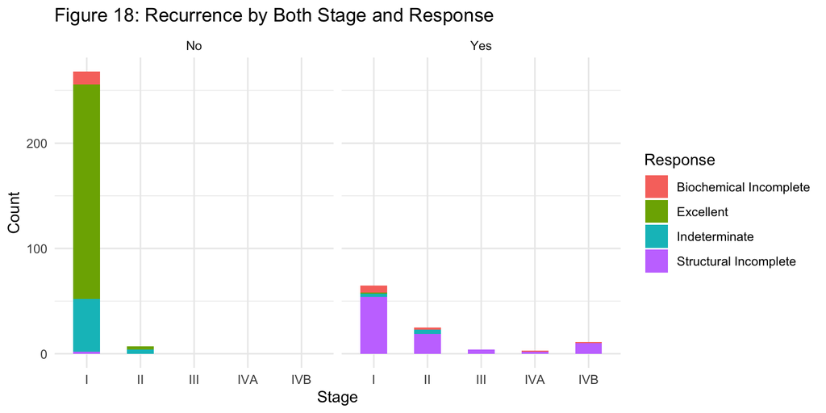

# 3 Data Analysis

## 3.1 Goal: What machine learning models can best predict thyroid cancer recurrence based on other variables in our dataset?

## 3.2 Approach:

- Split the data into training and testing sets (80/20 split)
- Apply SMOTE (Synthetic Minority Over-sampling Technique) to balance the data set’s `Reccurred` variable
- Apply One-Hot Encoding to the training and testing data sets
- Compare the following models on the training data set by using the metrics AUC and MCE.
  - 1. LASSO + Logistic Regression (train on SMOTE-balanced training data set that is one-hot encoded)
  - 2. Neural Network (train on SMOTE-balanced training data set that is one-hot encoded)
  - 3. Random Forest + Decision Tree (train on SMOTE training data set that is **not** one-hot encoded)

### 3.2.1 Analysis Part 1: Splitting Data into Training and Testing Sets

- Goal: Split the data into training and testing sets (80/20 split)

### 3.2.2 Analysis Part 2: SMOTE to Balance the Training Dataset’s `Recurred` Variable (Response Variable)

- We applied **SMOTE** to our **training data set** before performing any modeling.
- SMOTE stands for **Synthetic Minority Over-sampling Technique**. It is a method used in imbalanced classification problems to address the issue where the predicted class (in our case, `Recurred`) has far fewer examples than the other.
- To be more specific, SMOTE generates new (“synthetic”) data points of the minority class (in our case `Recurred` - YES) by interpolation to create new, plausible points within the minority class region. It does this by selecting a minority example and generating new points along the line segments between it and its nearest minority neighbors in feature space.
- We used the `UBL` package’s `SmoteClassif` function to balance our data set. This function was built to handle categorical features properly using nearest neighbors that respect nominal features
- This function makes sense for out data frame because the predicted variable - `Recurred` - is a categorical, as are most predictor variables)
- In addition, **our data set meets the assumptions of the `SmoteClassif` algorithm: The target variable is a factor, and some predictors are factors too.**
- The **SMOTE-balanced training set** will be used for out models that are sensitive to class imbalance. These are:
  - **LASSO + Logistic Regression**
  - **Neural Network**
  - **Random Forest**

Training Data's Class Distribution Before SMOTE

| Recurrence | Count |
| --- | --- |
| No | 219 |
| Yes | 87 |

Training Data's Class Distribution After SMOTE

| Recurrence | Count |
| --- | --- |
| No | 219 |
| Yes | 218 |

- **As we can see, SMOTE balanced the `Recurred` variable in our training dataset**

### 3.2.3 Analysis Part 3: One-hot encoding of SMOTE training data set

- We perform one-hot encoding to convert categorical variables into binary (0/1) indicators, making them suitable for machine learning models that require numeric input.
- One-Hot encoding is a process of converting categorical variables into a binary (0 and 1) format that can be provided to machine learning algorithms to do a better job in prediction.
- In our case, we will use the `fastDummies` package to perform One-Hot encoding on our data set.
- In addition, we will set the most frequent level as reference for all factor variables. **It is important to set a reference level for the One-Hot Encoding Matrix, because it helps to avoid multicolinearity and ensure model idenifiability when using the dummy variables in modeling.**
- One-hot encoding will be used for models that require that cannot handle factor data directly (such as LASSO and neural network). These include the following models that we perform in our analysis:
  - **LASSO + Logistic Regression**
  - **Neural Network**
  - Note: We will **not** use the one-hot encoded data for the **Random Forest** model. It does not require one-hot encoding, as it **can handle categorical variables directly**.

```
## Reference levels for factor variables:
```

```
## Variable: Gender
## [1] "Levels: F, M"
## [1] "Reference level: F"
##
## Variable: Smoking
## [1] "Levels: No, Yes"
## [1] "Reference level: No"
##
## Variable: Hx.Smoking
## [1] "Levels: No, Yes"
## [1] "Reference level: No"
##
## Variable: Hx.Radiothreapy
## [1] "Levels: No, Yes"
## [1] "Reference level: No"
##
## Variable: Thyroid.Function
## [1] "Levels: Euthyroid, Clinical Hyperthyroidism, Clinical Hypothyroidism, Subclinical Hyperthyroidism, Subclinical Hypothyroidism"
## [1] "Reference level: Euthyroid"
##
## Variable: Physical.Examination
## [1] "Levels: Normal, Multinodular goiter, Diffuse goiter, Single nodular goiter-left, Single nodular goiter-right"
## [1] "Reference level: Normal"
##
## Variable: Adenopathy
## [1] "Levels: No, Bilateral, Extensive, Left, Posterior, Right"
## [1] "Reference level: No"
##
## Variable: Pathology
## [1] "Levels: Papillary, Follicular, Hurthel cell, Micropapillary"
## [1] "Reference level: Papillary"
##
## Variable: Focality
## [1] "Levels: Uni-Focal, Multi-Focal"
## [1] "Reference level: Uni-Focal"
##
## Variable: Risk
## [1] "Levels: Low, High, Intermediate"
## [1] "Reference level: Low"
##
```

[output cut: 8 more lines]

```
## Variable: M
## [1] "Levels: M0, M1"
## [1] "Reference level: M0"
##
## Variable: Stage
## [1] "Levels: I, II, III, IVA, IVB"
## [1] "Reference level: I"
##
## Variable: Response
## [1] "Levels: Indeterminate, Structural Incomplete, Biochemical Incomplete, Excellent"
## [1] "Reference level: Indeterminate"
##
## Variable: Recurred
## [1] "Levels: No, Yes"
## [1] "Reference level: No"
```

```
## One-hot encoding was applied; Here are the first five rows of the one-hot encoded training data matrix:
```

**First five observations – after applying One-Hot Encoding to Training data**

| Age | Gender_M | Smoking_Yes | Hx.Smoking_Yes | Hx.Radiothreapy_Yes | Thyroid.Function_Clinical Hyperthyroidism | Thyroid.Function_Clinical Hypothyroidism | Thyroid.Function_Subclinical Hyperthyroidism | Thyroid.Function_Subclinical Hypothyroidism | Physical.Examination_Multinodular goiter | Physical.Examination_Diffuse goiter | Physical.Examination_Single nodular goiter-left | Physical.Examination_Single nodular goiter-right | Adenopathy_Bilateral | Adenopathy_Extensive | Adenopathy_Left | Adenopathy_Posterior | Adenopathy_Right | Pathology_Follicular | Pathology_Hurthel cell | Pathology_Micropapillary | Focality_Multi-Focal | Risk_High | Risk_Intermediate | T_T2 | T_T1b | T_T3a | T_T3b | T_T4a | T_T4b | … |
| --- | --- | --- | --- | --- | --- | --- | --- | --- | --- | --- | --- | --- | --- | --- | --- | --- | --- | --- | --- | --- | --- | --- | --- | --- | --- | --- | --- | --- | --- | --- |
| 38 | 0 | 0 | 0 | 0 | 0 | 0 | 0 | 0 | 0 | 0 | 0 | 1 | 0 | 0 | 0 | 0 | 0 | 0 | 0 | 0 | 0 | 0 | 0 | 1 | 0 | 0 | 0 | 0 | 0 | … |
| 50 | 0 | 0 | 0 | 0 | 1 | 0 | 0 | 0 | 1 | 0 | 0 | 0 | 0 | 0 | 0 | 0 | 0 | 0 | 0 | 1 | 0 | 0 | 0 | 0 | 0 | 0 | 0 | 0 | 0 | … |
| 26 | 0 | 0 | 0 | 0 | 0 | 0 | 0 | 0 | 0 | 0 | 0 | 1 | 0 | 0 | 0 | 0 | 0 | 0 | 0 | 0 | 0 | 0 | 0 | 1 | 0 | 0 | 0 | 0 | 0 | … |
| 23 | 0 | 0 | 0 | 0 | 0 | 0 | 0 | 0 | 1 | 0 | 0 | 0 | 0 | 0 | 0 | 0 | 0 | 0 | 0 | 0 | 1 | 0 | 0 | 1 | 0 | 0 | 0 | 0 | 0 | … |
| 52 | 0 | 0 | 0 | 0 | 0 | 0 | 0 | 0 | 1 | 0 | 0 | 0 | 0 | 0 | 0 | 0 | 0 | 1 | 0 | 0 | 0 | 0 | 0 | 0 | 0 | 1 | 0 | 0 | 0 | … |
| 35 | 0 | 0 | 0 | 0 | 0 | 0 | 0 | 0 | 0 | 0 | 0 | 1 | 0 | 0 | 0 | 0 | 0 | 0 | 0 | 0 | 0 | 0 | 0 | 1 | 0 | 0 | 0 | 0 | 0 | … |

```
##
## One-hot encoding was applied; Here are the first five rows of the one-hot encoded testing data matrix:
```

**First five observations – after applying One-Hot Encoding to Testing data**

| Age | Gender_M | Smoking_Yes | Hx.Smoking_Yes | Hx.Radiothreapy_Yes | Thyroid.Function_Clinical Hyperthyroidism | Thyroid.Function_Clinical Hypothyroidism | Thyroid.Function_Subclinical Hyperthyroidism | Thyroid.Function_Subclinical Hypothyroidism | Physical.Examination_Multinodular goiter | Physical.Examination_Diffuse goiter | Physical.Examination_Single nodular goiter-left | Physical.Examination_Single nodular goiter-right | Adenopathy_Bilateral | Adenopathy_Extensive | Adenopathy_Left | Adenopathy_Posterior | Adenopathy_Right | Pathology_Follicular | Pathology_Hurthel cell | Pathology_Micropapillary | Focality_Multi-Focal | Risk_High | Risk_Intermediate | T_T2 | T_T1b | T_T3a | T_T3b | T_T4a | T_T4b | … |
| --- | --- | --- | --- | --- | --- | --- | --- | --- | --- | --- | --- | --- | --- | --- | --- | --- | --- | --- | --- | --- | --- | --- | --- | --- | --- | --- | --- | --- | --- | --- |
| 67 | 1 | 1 | 1 | 0 | 0 | 0 | 0 | 0 | 1 | 0 | 0 | 0 | 1 | 0 | 0 | 0 | 0 | 0 | 0 | 0 | 0 | 0 | 1 | 0 | 0 | 1 | 0 | 0 | 0 | … |
| 21 | 0 | 0 | 0 | 0 | 0 | 0 | 0 | 0 | 0 | 0 | 0 | 1 | 0 | 0 | 0 | 0 | 0 | 0 | 0 | 0 | 0 | 0 | 0 | 0 | 1 | 0 | 0 | 0 | 0 | … |
| 30 | 0 | 0 | 0 | 0 | 0 | 0 | 0 | 0 | 0 | 0 | 0 | 1 | 0 | 0 | 0 | 0 | 0 | 0 | 0 | 1 | 0 | 0 | 0 | 0 | 0 | 0 | 0 | 0 | 0 | … |
| 30 | 0 | 0 | 0 | 0 | 0 | 0 | 0 | 0 | 0 | 0 | 0 | 1 | 0 | 0 | 0 | 0 | 0 | 0 | 0 | 0 | 0 | 0 | 0 | 0 | 1 | 0 | 0 | 0 | 0 | … |
| 43 | 0 | 0 | 0 | 0 | 0 | 0 | 0 | 0 | 0 | 0 | 1 | 0 | 0 | 0 | 0 | 0 | 0 | 0 | 0 | 0 | 0 | 0 | 0 | 0 | 1 | 0 | 0 | 0 | 0 | … |
| 49 | 0 | 0 | 1 | 0 | 0 | 0 | 0 | 0 | 0 | 0 | 0 | 1 | 0 | 0 | 0 | 0 | 0 | 0 | 0 | 0 | 0 | 0 | 0 | 1 | 0 | 0 | 0 | 0 | 0 | … |

### 3.2.4 Analysis Part 4: **Model 1 - LASSO followed by Logistic Regression followed by Backwards Selection**

- **Goal:** Use LASSO to select the most important variables, and then use those variables to fit a logistic regression model.
- LASSO (Least Absolute Shrinkage and Selection Operator) is a regression analysis method that performs both variable selection and regularization to enhance the prediction accuracy and interpretability of the statistical model it produces.
- LASSO is particularly useful when we have a large number of predictors, and we want to identify the most important ones while also preventing overfitting.
- Logistic regression is a statistical method for predicting binary classes. Our outcome variable (`Recurred`) is a binary variable (0/1).
- **Use one-hot-encoded SMOTE-balanced training data set for LASSO.**
- **Then use the selected variables to fit a logistic regression model (on non-one-hot-encoded training dataset).**
- **Finally, use backwards selection to select the most important variables in the logistic regression model.**
  - We performed the backwards selection using the **drop1() function in R.** This **evaluates the impact of removing individual terms (predictors) from a fitted model**, one at a time, to assess whether their exclusion significantly degrades model fit. **It is based on the a likelihood ratio test (using chi-square distribution)**.
  - Importantly, for categorical variables, drop1() evaluates the entire factor as a unit (i.e., all its levels). This is particularly important for out dataset, as it contains mostly categorical variables.
  - In addition, Likelihood Ratio tests used in drop1() are more robust than Wald tests (Anova()) for logistic regression.

##### 3.2.4.0.1 Model Fitting

```
## Coefficient Estimates and Level-wise Significance:
```

Logistic Regression Coefficients (Wald Test) and Level-wise significance

| Variable and Level | Log-Odds Estimate | SE | p-value |
| --- | --- | --- | --- |
| (Intercept) | -21.764 | 6041.790 | 0.997 |
| Age | 0.095 | 0.031 | 0.002 |
| GenderM | 1.986 | 0.875 | 0.023 |
| TT2 | 12.421 | 6041.790 | 0.998 |
| TT1b | 15.380 | 6041.790 | 0.998 |
| TT3a | 14.553 | 6041.790 | 0.998 |
| TT3b | 18.933 | 6041.790 | 0.997 |
| TT4a | 18.548 | 6041.791 | 0.998 |
| TT4b | 30.852 | 10210.429 | 0.998 |
| NN1a | 3.649 | 1.139 | 0.001 |
| NN1b | 3.300 | 1.039 | 0.001 |
| PathologyFollicular | -0.426 | 1.229 | 0.729 |
| PathologyHurthel cell | -24.519 | 2776.205 | 0.993 |
| PathologyMicropapillary | -13.218 | 6041.790 | 0.998 |
| ResponseStructural Incomplete | 23.932 | 2776.203 | 0.993 |
| ResponseBiochemical Incomplete | 2.758 | 0.904 | 0.002 |
| ResponseExcellent | -2.889 | 1.254 | 0.021 |

```
## Overall Variable Significance:
```

Overall Variable Importance (Likelihood Ratio Test via drop1)

| Variable | Degrees of Freedom | p-value | LRT Statistic |
| --- | --- | --- | --- |
| Age | 1 | 0.0005 | 11.99 |
| Gender | 1 | 0.0181 | 5.58 |
| T | 6 | 0.0020 | 20.83 |
| N | 2 | 0.0000 | 19.91 |
| Pathology | 3 | 0.0075 | 11.97 |
| Response | 3 | 0.0000 | 159.30 |

##### 3.2.4.0.2 Model Testing

```
## 53 2 1 20
```

```
## Accuracy:  0.9605
```

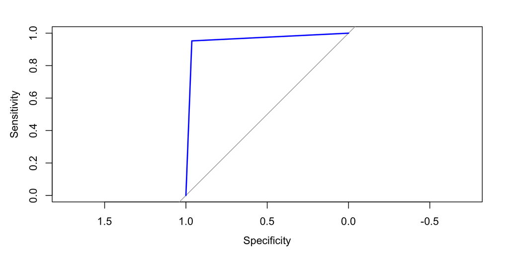

```
## Area Under Curve:  0.958
```

- The **classification threshold** we used was 0.5
- **Final Model Metrics**
  - **Accuracy: 0.9605**
  - **Area Under Curve: 0.958**

### 3.2.5 Analysis Part 5: **Model 2 - Neural Network**

##### 3.2.5.0.1 Model Fitting

- We used the `Keras` package to build the neural network model, which included:
  - One hidden layer with 20 neurons
  - ReLU activation function in the hidden layer
  - Sigmoid activation in the output layer (appropriate for binary classification)
  - An 85%/15% internal split of the training data for training and validation, respectively
- We can try **interpret the neural network model using the DALEX package.**
  - **DALEX = Descriptive mAchine Learning EXplanations**, a model-agnostic framework for interpreting complex models such as neural networks.
  - The **model_parts() function in DALEX** provides global interpretability to the neural network model, by quantifying how much each input feature contributes to the model’s overall predictive performance.
  - It does this by permuting individual features and **measuring how much the model’s performance (in our case, RMSE) deteriorates when each feature is shuffled, indicating its importance**.
  - **Overall, DALEX allows us to rank features by their global contribution to prediction accuracy.** In our case, since we had to use one-hot encoding matrix to train our data, **DALEX will interpret the importance of each categorical variable level.**

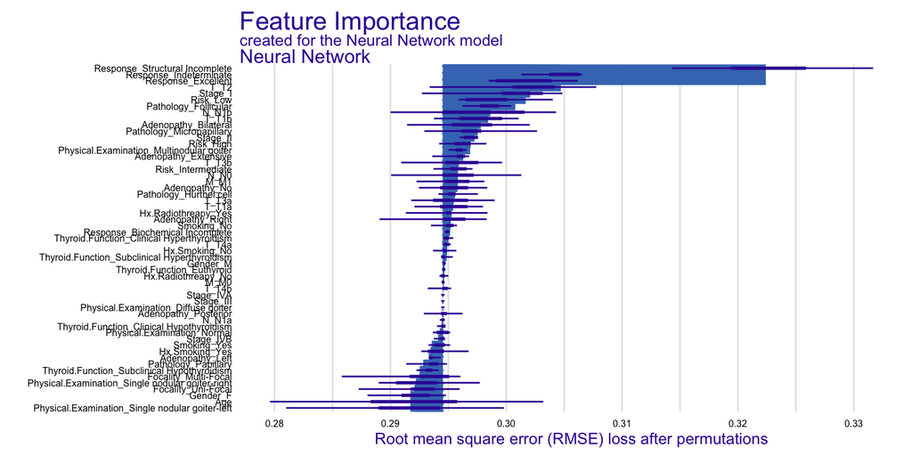

##### 3.2.5.0.2 Model Testing

- We evaluated the performance of the neural network by using the **one-hot-encoded testing data set** (We evaluated the performance of the neural network using the one-hot encoded testing data set with all levels retained; i.e., no reference level was dropped).

```
## 3/3 - 0s - 38ms/epoch - 13ms/step
```

```
## Accuracy:
```

```
## 0.908
```

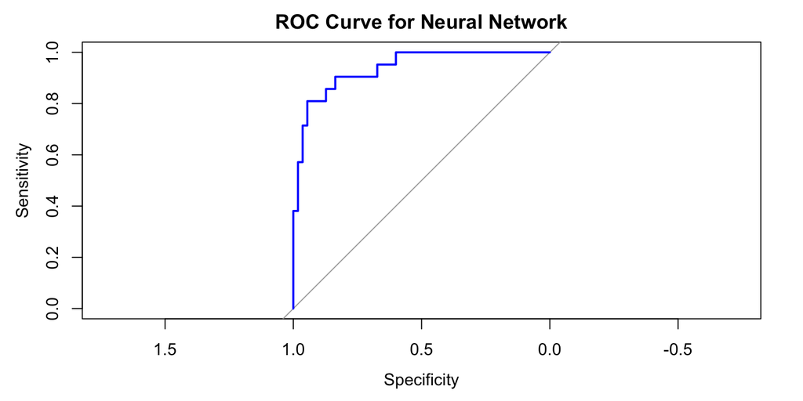

```
## AUC:
```

```
## 0.938
```

```
## Confusion Matrix:
```

```
##          Actual
## Predicted  0  1
##         0 52  4
##         1  3 17
```

### 3.2.6 Analysis Part 6: **Model 3 - Random Forest**

- We applied the **Random Forest** algorithm to our **SMOTE-balanced training data set**.
  - **One-hot encoding** was **not** applied, as Random Forest in R can natively handle categorical variables encoded as factors.
  - Therefore, the data’s structure is preserved, and the model can retain the categorical nature of the variables and split on sets of factor levels in a single decision rule, instead of evaluating levels one-by-one.

##### 3.2.6.0.1 Model Fitting

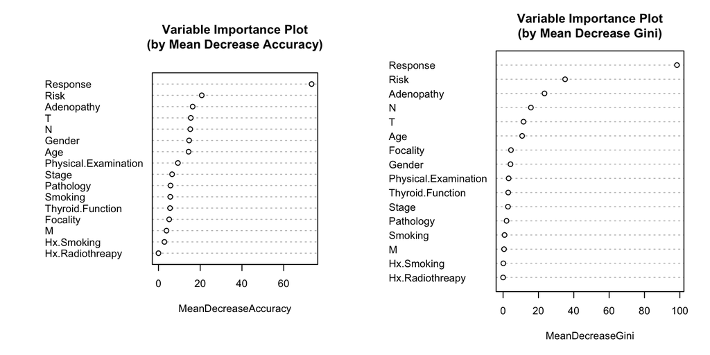

- We can try to interpret the random forest model using the variable importance based on two metrics:
  - **MeanDecreaseGini**: Total decrease in Gini Impurity across all trees when a given variable is used to split.
  - Gini Impurity measures the probability that a randomly chosen observation would be misclassified if it were randomly labeled according to the class distribution in a node. Ie, its a measure of how “mixed” the classes are in a decision tree node.
  - **Variables with high MeanDecreaseGini are more important and frequently used to make good splits across the forest**.
  - **MeanDecreaseAccuracy**: Indicates how much model accuracy drops when each variable is permuted (randomized). H
    - **Variables with high MeanDecreaseAccuracy are more important and more crucial to predictive power**.
- **In our random forest model, the most important variables (based on MeanDecreaseGini and MeanDecreaseAccuracy)** are:
  - `Response`
  - `Risk`
  - `Adenopathy`
  - `N`
  - `T`
  - `Age`
  - `Gender`

##### 3.2.6.0.2 Model Testing

[output not shown]

```
## Accuracy: 0.9379
```

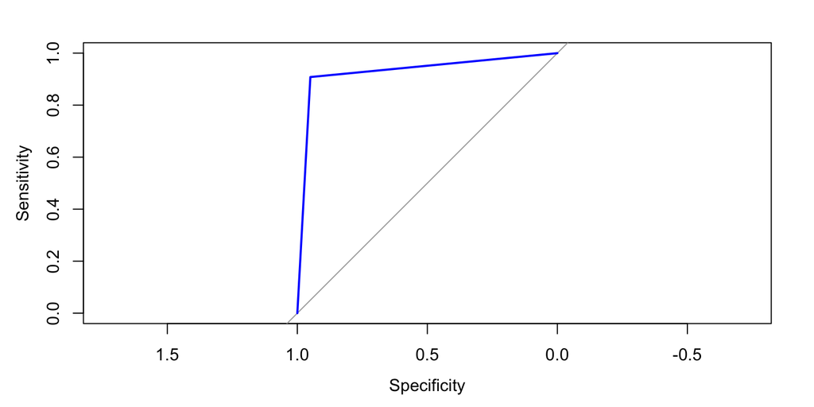

```
## Area Under Curve:  0.9289
```